# ENSANUT EC 2019

Jorge Andrés Delgado-Ron

11/12/2020

# About

This is an R guide to work with the 2018-2019 National Health Survey of Ecuador. If you want to know more about this survey, go to https://www.ecuadorencifras.gob.ec/salud-salud-reproductiva-y-nutricion/

All the files are open access and can be downloaded [here](https://www.ecuadorencifras.gob.ec/documentos/web-inec/Estadisticas_Sociales/ENSANUT/ENSANUT_2018/). However, I re-uploaded them to OSF to import them with R Studio:

# Required packages

```r
install.packages("osfr")
install.packages("fabricatr")
options("scipen" = 20)
```

# Importing the datasets

```r
library(osfr)
ENSANUT_EC <- osf_retrieve_node("https://osf.io/e3pgz/")
ENSANUT_DIRECTORY  <- osf_ls_files(ENSANUT_EC)
ENSANUT_DIRECTORY ## See files

osf_download(ENSANUT_DIRECTORY, path = getwd(), conflicts = "overwrite", progress = T) ## Downloading the files to the local directory

#Independent questionnaires

People <- read.csv("~/R/1_BDD_ENS2018_f1_personas.csv", numerals = "no.loss", encoding = "UTF-8")
Household <- read.csv("~/R/2_BDD_ENS2018_f1_hogar.csv", numerals = "no.loss", encoding = "UTF-8")
Food_labels <- read.csv("~/R/3_BDD_ENS2018_f1_etiqueta.csv", numerals = "no.loss", encoding = "UTF-8")
Fertile_women <- read.csv("~/R/4_BDD_ENS2018_f2_mef.csv", numerals = "no.loss", encoding = "UTF-8") # Women 10 to 49
Lactancia <- read.csv("~/R/5_BDD_ENS2018_f2_lactancia.csv", numerals = "no.loss", encoding = "UTF-8") # Last child under 3 (breastfeeding)
Child_health <- read.csv("~/R/6_BDD_ENS2018_f2_salud_ninez.csv", numerals = "no.loss", encoding = "UTF-8") #Health children under 5
SexualHealth <- read.csv("~/R/7_BDD_ENS2018_f3_ssrh.csv", numerals = "no.loss", encoding = "UTF-8") #Men over 12
Risk_factors <- read.csv("~/R/8_BDD_ENS2018_f4_fact_riesgo.csv", numerals = "no.loss", encoding = "UTF-8") #5 to 17
Development <- read.csv("~/R/9_BDD_ENS2018_f5_des_inf.csv", numerals = "no.loss", encoding = "UTF-8") # Under 5, childhood development
```

## Selecting the main dataset (and associated variables).

The dataset selection must be based on your unit of analysis. My unit of analysis is children under 5, hence I will work with “Development” as my main data frame.

```r
# List of variables I am going to use, first include all weights and identifiers available.
weights_and_identifiers <- c("upm", "id_viv", "id_hogar", "id_per", "id_mef", "persona", "fexp", "estrato")

#Include any variable you may use for sampling purposes
sampling_var <- c("f5_s5_500")

#Then include all other covariates you will use in your model either exposure, outcome, mediators, instrumental variables, or covariates
all_other_vars <- c('f5_s5_501', 'f5_s5_502', 'f5_s5_503', 'f5_s5_504', 'f5_s5_505', 'f5_s5_506', 'f5_s5_507', 'f5_s5_508', 'f5_s5_509', 'f5_s5_510', 'f5_s2_200', 'f5_s2_204_1', 'f5_s2_204_2', 'f5_s5_511', 'f5_s14_1402', 'gedad_meses', 'etnia', 'edadanios_mef', 'sexo', 'area')
Main_database_vars <- c(weights_and_identifiers,sampling_var,all_other_vars)

Df <- Development[Main_database_vars]
```

# Linking datasets:

We are going to link datasets one by one. The reason being that you won’t necessarily use the same identifier. Hence, we recommend using different R chunks each time you merge a dataset (so you can use the one below as a template) ## First merging process

```r
#Get familiar with identifiers in your new dataset: Child_health
head(Child_health[,1:10])
```

```
##     area prov       upm    id_viv  id_hogar            id_per           id_hijo
## 1 urbano    1 1.015e+10 1.015e+12 1.015e+13 01015000020102103 01015000020102107
## 2 urbano    1 1.015e+10 1.015e+12 1.015e+13 01015000020103103 01015000020103106
## 3 urbano    1 1.015e+10 1.015e+12 1.015e+13 01015000020104102 01015000020104107
## 4 urbano    1 1.015e+10 1.015e+12 1.015e+13 01015000020104104 01015000020104108
## 5 urbano    1 1.015e+10 1.015e+12 1.015e+13 01015000020114103 01015000020114105
## 6 urbano    1 1.015e+10 1.015e+12 1.015e+13 01015000020117102 01015000020117103
##            id_hijo_ord id_ord persona
## 1 01015000020102103071      1       7
## 2 01015000020103103061      1       6
## 3 01015000020104102071      1       7
## 4 01015000020104104081      1       8
## 5 01015000020114103051      1       5
## 6 01015000020117102031      1       3
```

```r
#Get familiar with the identifiers of the main dataset:
head(Df[,1:6])
```

```
##         upm    id_viv  id_hogar            id_per            id_mef persona
## 1 1.015e+10 1.015e+12 1.015e+13 01015000020101106 01015000020101102       6
## 2 1.015e+10 1.015e+12 1.015e+13 01015000020102107 01015000020102103       7
## 3 1.015e+10 1.015e+12 1.015e+13 01015000020103106 01015000020103103       6
## 4 1.015e+10 1.015e+12 1.015e+13 01015000020104107 01015000020104102       7
## 5 1.015e+10 1.015e+12 1.015e+13 01015000020114105 01015000020114103       5
## 6 1.015e+10 1.015e+12 1.015e+13 01015000020117103 01015000020117102       3
```

```r
#Identify the variables required to link the dataset. In my case, I need to find 'id_hijo' in Child_health to match 'id_per' in Df:

link01 <- "id_hijo" #You will delete this variable later because both datasets need to have the same identifier.
target_variable <- "id_per"

#Now list the variables you need to import from said dataset:

vars_01 <- c('f2_s4a_403_', 'f2_s4a_405_', 'nivins_mef', 'dcronica')

merge_list_01 <- c(link01,vars_01)

#Now I am creating a smaller dataset to merge it with the main one
OtherData1 <- Child_health[merge_list_01]

#but first we need to make the identifiers match

OtherData1$id_per <- OtherData1$id_hijo
OtherData1$id_hijo <- NULL # Told you
head(OtherData1)
```

```
##                   f2_s4a_403_                 f2_s4a_405_
## 1 quería esperar mas tiempo ? quería esperar mas tiempo ?
## 2 quería esperar mas tiempo ?             tener ese hijo?
## 3        no quería más hijos?        no quería más hijos?
## 4             tener ese hijo?             tener ese hijo?
## 5 quería esperar mas tiempo ?             tener ese hijo?
## 6             tener ese hijo?             tener ese hijo?
##                     nivins_mef dcronica            id_per
## 1                     Superior        0 01015000020102107
## 2             Educación Básica        0 01015000020103106
## 3             Educación Básica        1 01015000020104107
## 4 Educación Media/Bachillerato        0 01015000020104108
## 5                     Superior        1 01015000020114105
## 6 Educación Media/Bachillerato        0 01015000020117103
```

```r
#Merging
Merged01 <- merge(Df, OtherData1, by=target_variable, all.x = T)
```

## Second merging process

```r
#Get familiar with identifiers in your new dataset: Household
head(Household[,1:10])
```

```
##     area prov       upm    id_viv  id_hogar
## 1 urbano    1 1.015e+10 1.015e+12 1.015e+13
## 2 urbano    1 1.015e+10 1.015e+12 1.015e+13
## 3 urbano    1 1.015e+10 1.015e+12 1.015e+13
## 4 urbano    1 1.015e+10 1.015e+12 1.015e+13
## 5 urbano    1 1.015e+10 1.015e+12 1.015e+13
## 6 urbano    1 1.015e+10 1.015e+12 1.015e+13
##                                     f1_s1_1      f1_s1_2                f1_s1_3
## 1 carretera/ calle pavimentada o adoquinada casa o villa                  zinc?
## 2 carretera/ calle pavimentada o adoquinada departamento      asbesto(eternit)?
## 3 carretera/ calle pavimentada o adoquinada casa o villa                  zinc?
## 4 carretera/ calle pavimentada o adoquinada casa o villa      asbesto(eternit)?
## 5 carretera/ calle pavimentada o adoquinada departamento hormigón/losa/cemento?
## 6 carretera/ calle pavimentada o adoquinada casa o villa                  teja?
##                                                        f1_s1_4
## 1                                      cerámica/baldosa/vinyl?
## 2 duela/ parquet/ tabloncillo/ tablón tratado/ piso flotante ?
## 3 duela/ parquet/ tabloncillo/ tablón tratado/ piso flotante ?
## 4 duela/ parquet/ tabloncillo/ tablón tratado/ piso flotante ?
## 5                                      cerámica/baldosa/vinyl?
## 6                                      cerámica/baldosa/vinyl?
##                     f1_s1_5
## 1              adobe/tapia?
## 2              adobe/tapia?
## 3 hormigón/bloque/ladrillo?
## 4 hormigón/bloque/ladrillo?
## 5 hormigón/bloque/ladrillo?
## 6 hormigón/bloque/ladrillo?
```

```r
#Get familiar with the identifiers of the main dataset:
head(Merged01[,1:6])
```

```
##              id_per       upm    id_viv  id_hogar            id_mef persona
## 1 01015000020101106 1.015e+10 1.015e+12 1.015e+13 01015000020101102       6
## 2 01015000020102107 1.015e+10 1.015e+12 1.015e+13 01015000020102103       7
## 3 01015000020103106 1.015e+10 1.015e+12 1.015e+13 01015000020103103       6
## 4 01015000020104107 1.015e+10 1.015e+12 1.015e+13 01015000020104102       7
## 5 01015000020114105 1.015e+10 1.015e+12 1.015e+13 01015000020114103       5
## 6 01015000020117103 1.015e+10 1.015e+12 1.015e+13 01015000020117102       3
```

```r
#Identify the variables required to link the dataset. In my case, I need to find 'id_viv' in Child_health to match 'id_viv' in Merged01:

link02 <- "id_hogar" #No deletions this time
target_variable <- "id_hogar"

#Now list the variables you need to import from said dataset:

vars_02 <- c('f1_s1_42','f1_s1_44_7','f1_s1_44_1','f1_s1_44_2','f1_s1_44_3','f1_s1_44_4','f1_s1_24','f1_s1_44_6','f1_s1_44_9','f1_s1_44_10','f1_s1_44_8','f1_s1_4','f1_s1_3','f1_s1_7')

merge_list_02 <- c(link02,vars_02)

#Now I am creating a smaller dataset to merge it with the main one
OtherData2 <- Household[merge_list_02]
head(OtherData2)
```

```
##    id_hogar f1_s1_42 f1_s1_44_7 f1_s1_44_1 f1_s1_44_2 f1_s1_44_3 f1_s1_44_4
## 1 1.015e+13       si         si         si         si         si         si
## 2 1.015e+13       no         si         si         no         no         si
## 3 1.015e+13       si         si         si         si         si         si
## 4 1.015e+13       si         si         si         si         si         si
## 5 1.015e+13       no         si         si         no         no         si
## 6 1.015e+13       si         si         si         si         si         si
##                             f1_s1_24 f1_s1_44_6 f1_s1_44_9 f1_s1_44_10
## 1 por tubería dentro de la vivienda?         si         si          no
## 2 por tubería dentro de la vivienda?         no         si          no
## 3 por tubería dentro de la vivienda?         si         no          no
## 4 por tubería dentro de la vivienda?         si         si          no
## 5 por tubería dentro de la vivienda?         si         no          no
## 6 por tubería dentro de la vivienda?         si         no          si
##   f1_s1_44_8                                                      f1_s1_4
## 1         no                                      cerámica/baldosa/vinyl?
## 2         no duela/ parquet/ tabloncillo/ tablón tratado/ piso flotante ?
## 3         si duela/ parquet/ tabloncillo/ tablón tratado/ piso flotante ?
## 4         si duela/ parquet/ tabloncillo/ tablón tratado/ piso flotante ?
## 5         no                                      cerámica/baldosa/vinyl?
## 6         no                                      cerámica/baldosa/vinyl?
##                  f1_s1_3 f1_s1_7
## 1                  zinc?       4
## 2      asbesto(eternit)?       5
## 3                  zinc?       4
## 4      asbesto(eternit)?       5
## 5 hormigón/losa/cemento?       2
## 6                  teja?       5
```

```r
#Now the dataset is ready to be merged. We will do it once we have repeated the above process with all the required datasets.
Merged02 <- merge(Merged01, OtherData2, by=target_variable, all.x = T)
```

## Third merging process

```r
#Get familiar with identifiers in your new dataset: Household
head(Fertile_women[,1:10])
```

```
##     area prov       upm    id_viv  id_hogar            id_per persona
## 1 urbano    1 1.015e+10 1.015e+12 1.015e+13 01015000020102101       1
## 2 urbano    1 1.015e+10 1.015e+12 1.015e+13 01015000020102103       3
## 3 urbano    1 1.015e+10 1.015e+12 1.015e+13 01015000020102106       6
## 4 urbano    1 1.015e+10 1.015e+12 1.015e+13 01015000020103103       3
## 5 urbano    1 1.015e+10 1.015e+12 1.015e+13 01015000020103105       5
## 6 urbano    1 1.015e+10 1.015e+12 1.015e+13 01015000020104102       2
##   f2_s1_100_1 f2_s1_100_2 f2_s1_100_3
## 1          16          11        1982
## 2          16           7        1999
## 3           6          11        2000
## 4          25           4        1995
## 5          19           9        2000
## 6          29           6        1980
```

```r
#Get familiar with the identifiers of the main dataset:
head(Merged02[,1:6])
```

```
##    id_hogar            id_per       upm    id_viv            id_mef persona
## 1 1.015e+13 01015000020101106 1.015e+10 1.015e+12 01015000020101102       6
## 2 1.015e+13 01015000020102107 1.015e+10 1.015e+12 01015000020102103       7
## 3 1.015e+13 01015000020103106 1.015e+10 1.015e+12 01015000020103103       6
## 4 1.015e+13 01015000020104107 1.015e+10 1.015e+12 01015000020104102       7
## 5 1.015e+13 01015000020114105 1.015e+10 1.015e+12 01015000020114103       5
## 6 1.015e+13 01015000020117103 1.015e+10 1.015e+12 01015000020117102       3
```

```r
#Identify the variables required to link the dataset. In my case, I need to find 'id_per' in Fertile_women to match 'id_mef' in Merged02:

link03 <- "id_per"
target_variable <- "id_mef"

#Now list the variables you need to import from said dataset:

vars_03 <- c('f2_s9_900')

merge_list_03 <- c(link03,vars_03)

#Now I am creating a smaller dataset to merge it with the main one
OtherData3 <- Fertile_women[merge_list_03]
head(OtherData3)
```

```
##              id_per    f2_s9_900
## 1 01015000020102101 unión libre?
## 2 01015000020102103 unión libre?
## 3 01015000020102106 unión libre?
## 4 01015000020103103    separado?
## 5 01015000020103105     soltero?
## 6 01015000020104102 unión libre?
```

```r
#but first we need to make the identifiers match. We are just turning the personal identifier from the fertile women dataset into the identifier of the mother in the development dataset.
OtherData3$id_mef <- OtherData3$id_per
OtherData3$id_per <- NULL # Told you
head(OtherData3)
```

```
##      f2_s9_900            id_mef
## 1 unión libre? 01015000020102101
## 2 unión libre? 01015000020102103
## 3 unión libre? 01015000020102106
## 4    separado? 01015000020103103
## 5     soltero? 01015000020103105
## 6 unión libre? 01015000020104102
```

```r
#Now the dataset is ready to be merged. We will do it once we have repeated the above process with all the required datasets.
Merged03 <- merge(Merged02, OtherData3, by=target_variable, all.x = T)
```

# Verify

Verify that you obtained all the variables you need from all the available datasets. If you still need to merge more datasets, create a new R chunk and merge again. If not, you can rename your last iteration with your preferred name in case you need to go back and merge a new dataset later.

```r
MyData <- Merged03
```

# Renaming, recoding, and creating derived variables

Now that you have all the information you need in a single dataset, you can start coding your variables following the OSF registration template. Let us talk about:

## Exposure

**Mistimed or unintended pregnancy** is measured using the ‘f2_s4a_403_’ variable, which asked women ’when you got pregnant, you wanted to…?  
* have that kid * wait more time * not have more kids * not have [my first] kid.

We transformed this into a binary variable with the first option coded as 0 and the other options coded as 1.

```r
MyData$f2_s4a_403_ <- as.factor(MyData$f2_s4a_403_)
summary(MyData$f2_s4a_403_[MyData$f5_s5_500 %in% "niños/as de 3 a menores de 5 años"]) #I am preserving all kids because I need their factors of expansion, but I will present summaries of the target population only
```

```
##        no quería más hijos?      no quería tener hijos?
##                         512                         199
## quería esperar mas tiempo ?             tener ese hijo?
##                        1029                        5172
##                        NA's
##                         501
```

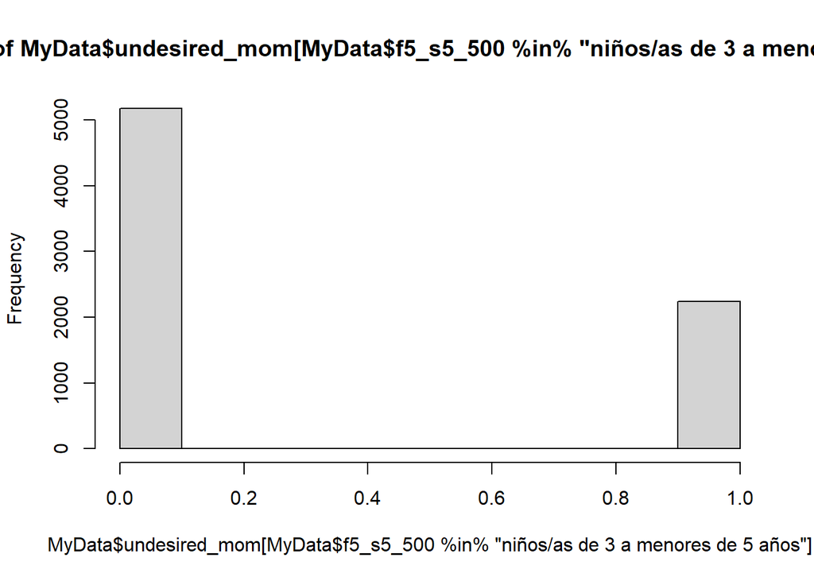

```r
MyData$undesired_mom <- ifelse(MyData$f2_s4a_403_ %in% "tener ese hijo?", 0,1)
hist(MyData$undesired_mom[MyData$f5_s5_500 %in% "niños/as de 3 a menores de 5 años"]) # 1 represents unintended or mistimed pregnancy
```

## Outcome

The main outcome is **Early Childhood Development** derived from four domains. Each domain is composed by a set of tasks the kid should (or should not) perform. Each domain has its own threshold.

| DOMAIN | Variables | Threshold |
| --- | --- | --- |
| Language/literacy and numeracy | f5_s5_501,f5_s5_502,f5_s5_503 | At least two |
| Physical | f5_s5_504, !f5_s5_505 | All |
| Cognitive development | f5_s5_506,f5_s5_507 | At least one |
| Social emotional | f5_s5_508, !f5_s5_509, !f5_s5_510 | At least two |

If the kid is proficient in three out of the four domains ("Tier II), we consider he or she has a normal development (coded as 1). Kids who did not meet this criterion were coded as 0.

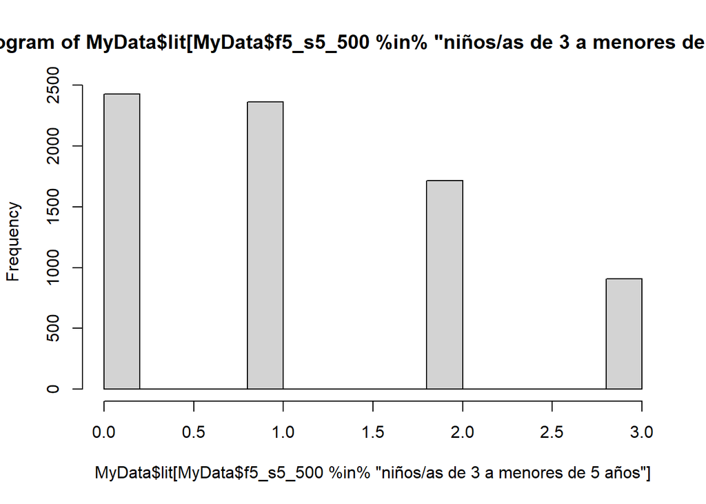

```r
MyData$f5_s5_501 <- as.factor(MyData$f5_s5_501)
MyData$f5_s5_502 <- as.factor(MyData$f5_s5_502)
MyData$f5_s5_503 <- as.factor(MyData$f5_s5_503)
MyData$f5_s5_504 <- as.factor(MyData$f5_s5_504)
MyData$f5_s5_505 <- as.factor(MyData$f5_s5_505)
MyData$f5_s5_506 <- as.factor(MyData$f5_s5_506)
MyData$f5_s5_507 <- as.factor(MyData$f5_s5_507)
MyData$f5_s5_508 <- as.factor(MyData$f5_s5_508)
MyData$f5_s5_509 <- as.factor(MyData$f5_s5_509)
MyData$f5_s5_510 <- as.factor(MyData$f5_s5_510)

#a. Perform at least two of these (Literacy_and_numeracy): f5_s5_501,f5_s5_502,f5_s5_503; and
MyData$lit1 <- ifelse(MyData$f5_s5_501 %in% "si",1,0)
MyData$lit2 <- ifelse(MyData$f5_s5_502 %in% "si",1,0)
MyData$lit3 <- ifelse(MyData$f5_s5_503 %in% "si",1,0)
MyData$lit <- MyData$lit1 + MyData$lit2 + MyData$lit3
hist(MyData$lit[MyData$f5_s5_500 %in% "niños/as de 3 a menores de 5 años"])
```

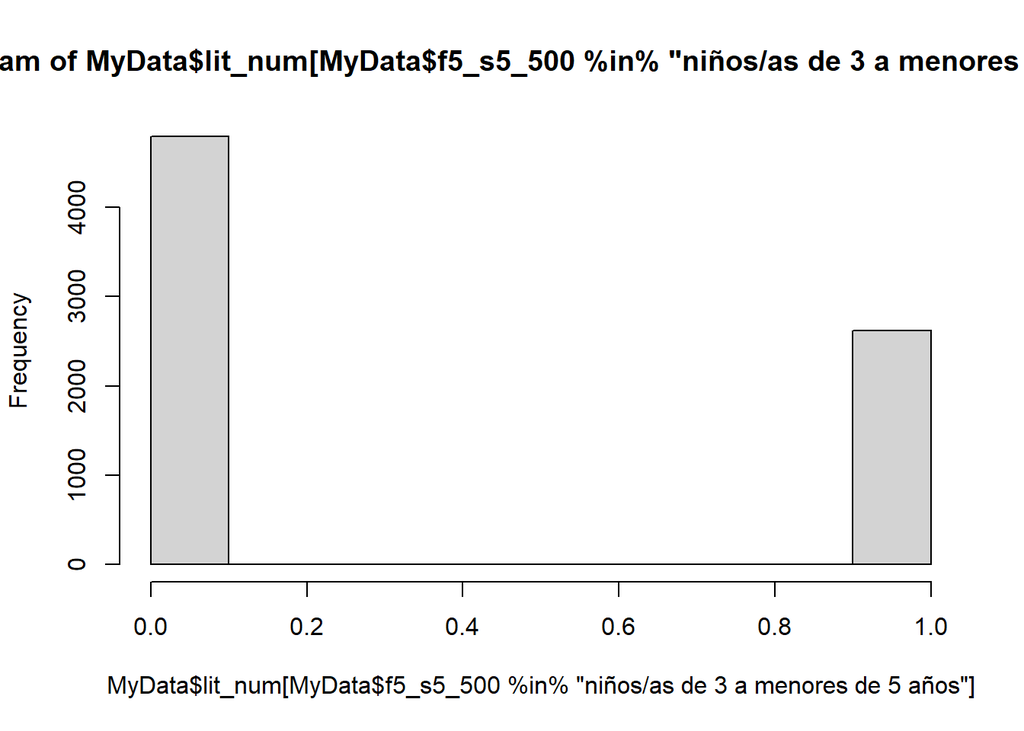

```r
MyData$lit_num <- ifelse (MyData$lit >= 2, 1, 0)
hist(MyData$lit_num[MyData$f5_s5_500 %in% "niños/as de 3 a menores de 5 años"])
```

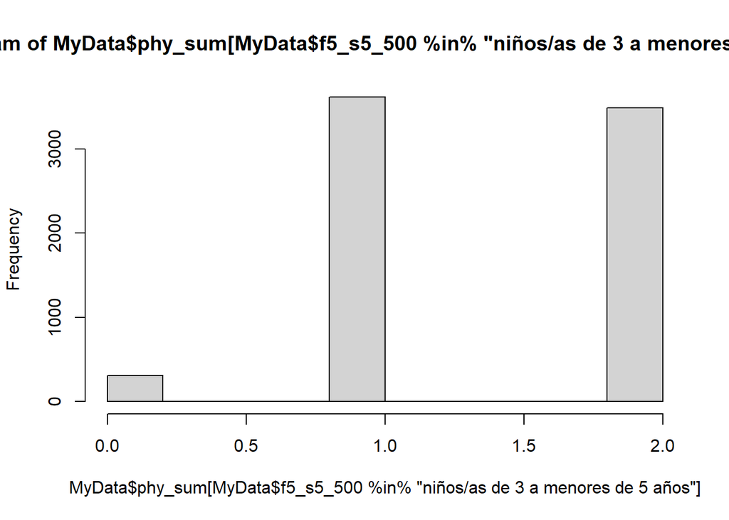

```r
#b. Perform both of these (Physical): f5_s5_504, !f5_s5_505; and
MyData$phy1 <- ifelse(MyData$f5_s5_504 %in% "si",1,0)
MyData$phy2 <- ifelse(MyData$f5_s5_505 %in% "no",1,0)
MyData$phy_sum <- MyData$phy1 + MyData$phy2
hist(MyData$phy_sum[MyData$f5_s5_500 %in% "niños/as de 3 a menores de 5 años"])
```

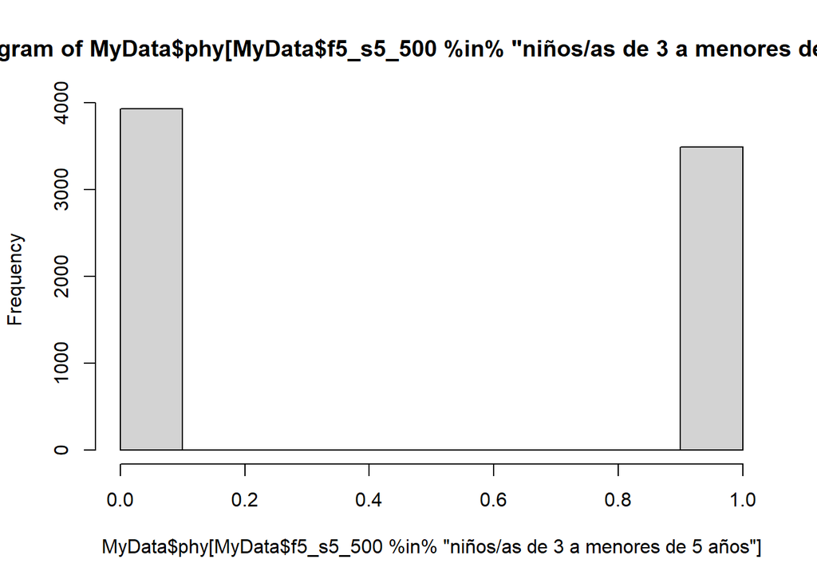

```r
MyData$phy <- ifelse (MyData$phy_sum > 1, 1, 0)
hist(MyData$phy[MyData$f5_s5_500 %in% "niños/as de 3 a menores de 5 años"])
```

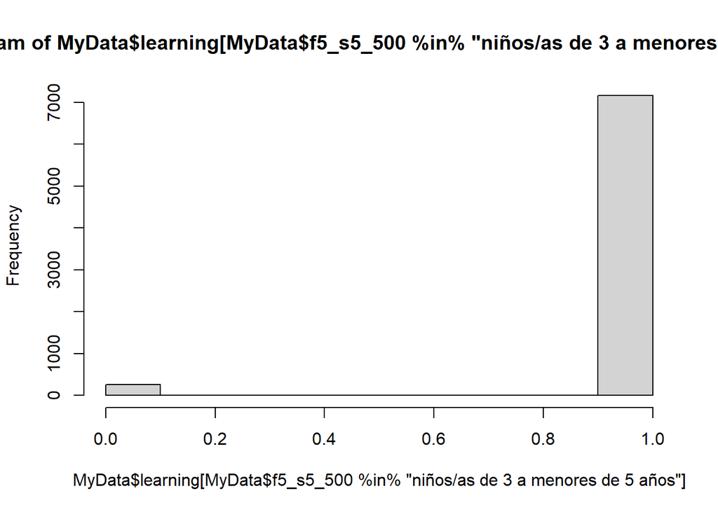

```r
#c. Perform at least one of these (Learning): f5_s5_506,f5_s5_507; and
MyData$lear1 <- ifelse(MyData$f5_s5_506 %in% "si",1,0)
MyData$lear2 <- ifelse(MyData$f5_s5_507 %in% "si",1,0)
MyData$learning <- ifelse(MyData$lear2+MyData$lear1>=1,1,0)
hist(MyData$learning[MyData$f5_s5_500 %in% "niños/as de 3 a menores de 5 años"])
```

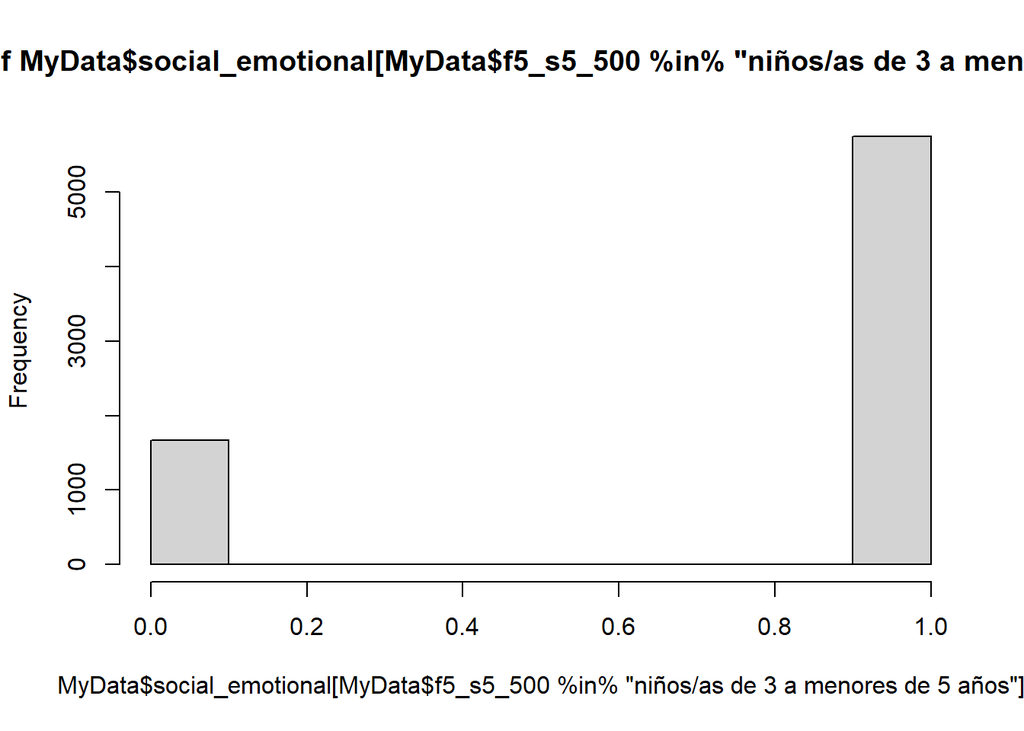

```r
#d. Perform at least two of these (Social_emotional): f5_s5_508, !f5_s5_509, !f5_s5_510
MyData$soc1 <- ifelse(MyData$f5_s5_508 %in% "si",1,0)
MyData$soc2 <- ifelse(MyData$f5_s5_509 %in% "no",1,0)
MyData$soc3 <- ifelse(MyData$f5_s5_510 %in% "no",1,0)
MyData$social <- MyData$soc1 + MyData$soc2 + MyData$soc3
MyData$social_emotional <- ifelse(MyData$social >=2,1,0)
hist(MyData$social_emotional[MyData$f5_s5_500 %in% "niños/as de 3 a menores de 5 años"])
```

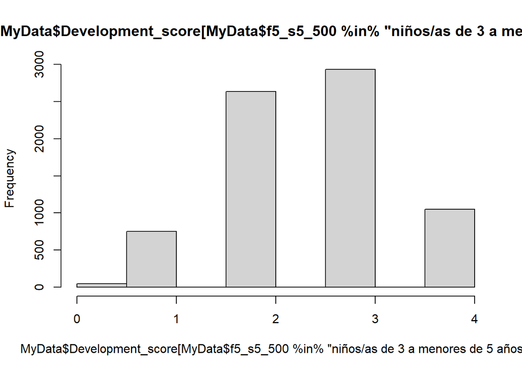

```r
MyData$Development_score <- MyData$lit_num+MyData$phy+MyData$learning+MyData$social_emotional
hist(MyData$Development_score[MyData$f5_s5_500 %in% "niños/as de 3 a menores de 5 años"])
```

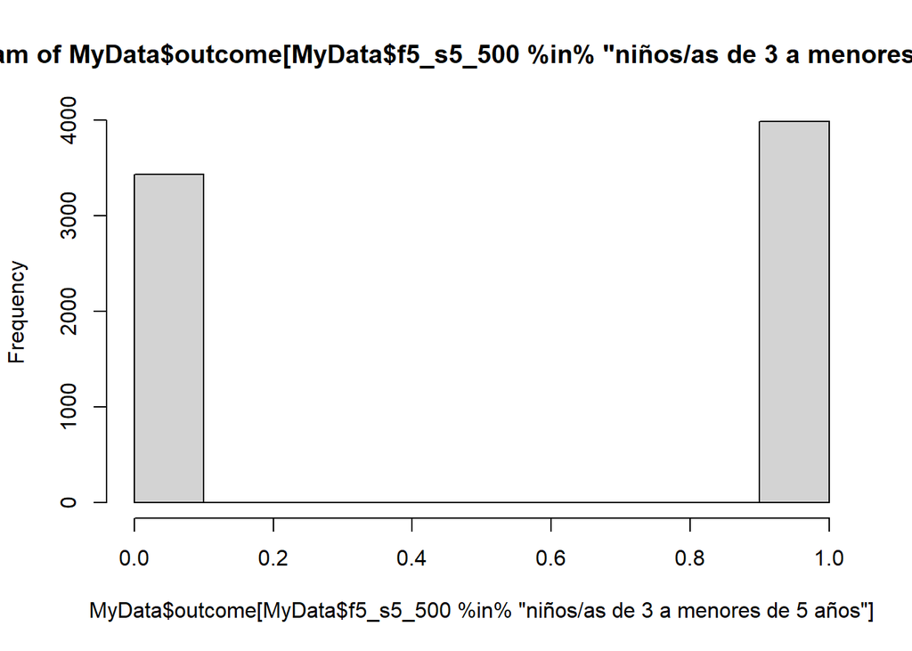

```r
MyData$outcome <- ifelse(MyData$Development_score >= 3,1,0)
hist(MyData$outcome[MyData$f5_s5_500 %in% "niños/as de 3 a menores de 5 años"])
```

## Confounders

We stated the assumed relationships between our variables using a directed acyclic graph. Based on these assumptions, we identified a set of covariates required for minimal sufficient adjustment: * Geographic area; * Household income; * Mistimed or unintended pregnancy according to the father; * The mother’s current marital status; * The mother’s current age; * The mother’s ethnicity; * The mother’s educational level; * Whether the mother present’s functional limitations related to depressive symptoms; * The child’s age; and * The number of months the child has attended a daycare.

### Geographic area

The geographic area (‘area’) is Classified as either urban or rural.

```r
MyData$area <- as.factor(MyData$area)
```

### Household income

Household income was built based on a list of indicators identified by a previous [study](http://www.revistas.espol.edu.ec/index.php/matematica/article/view/755) that aimed to built a wealth index with variables from the Ecuadorian National Health Survey using Principal Component Analysis and classifying their added value in quintires. We used a similar methodology. Access to internet (‘f1_s1_42’), tv(‘f1_s1_44_7’), fridge(‘f1_s1_44_1’), desktop computer(‘f1_s1_44_2’), laundry machine(‘f1_s1_44_3’), blender(‘f1_s1_44_4’), pipeline water(‘f1_s1_24’), iron(‘f1_s1_44_6’), heat(‘f1_s1_44_9’), landline (‘f1_s1_44_10’), and dvd player (‘f1_s1_44_8’) was coded as 1. Having a roof of concrete/slab/cement/tile/zinc was coded as 1 and roofs with other materials (Asbestos/Palm/straw/leaf/Other) were coded as 0. A similar process was followed for the floor (cement/brick/ceramic/tile/vinyl/stave/parquet/plank/treated plank/floating floor/marble/marmeton as 1 and board/untreated plank/Reed/Earth/Other as 0). Finally, the number of rooms was recoded to 1, 2, or 3 (more than two). We summed these variables and recoded the result by quintiles as a numeric variable (1 to 5).

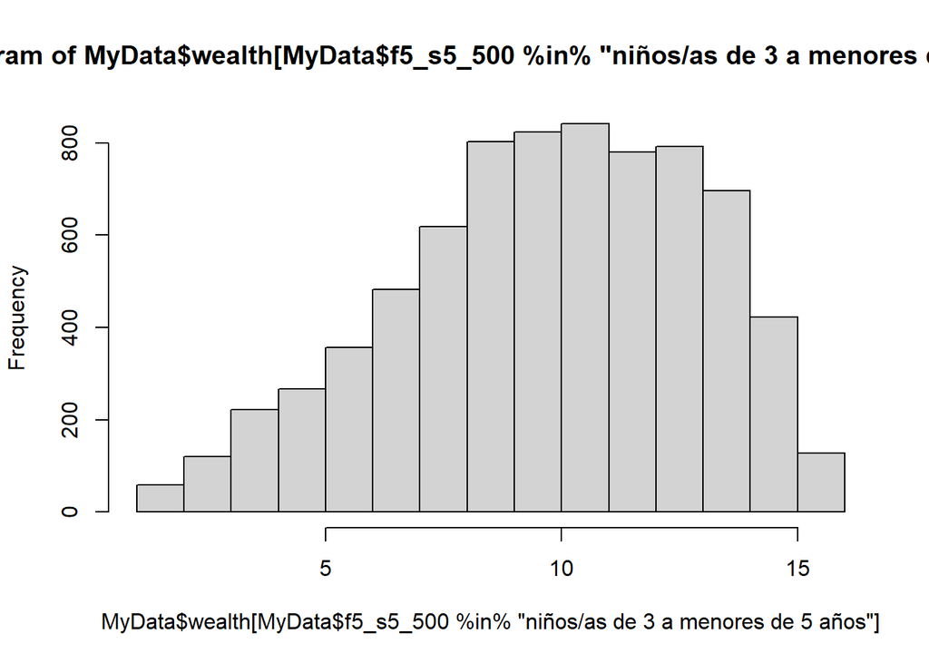

```r
MyData$f1_s1_42 <- as.factor(MyData$f1_s1_42)
MyData$internet <- ifelse(MyData$f1_s1_42 %in% "si",1,0)
MyData$f1_s1_44_7<- as.factor(MyData$f1_s1_44_7)
MyData$tv <- ifelse(MyData$f1_s1_44_7 %in% "si",1,0)
MyData$f1_s1_44_1<- as.factor(MyData$f1_s1_44_1)
MyData$fridge <- ifelse(MyData$f1_s1_44_1 %in% "si",1,0)
MyData$f1_s1_44_2<- as.factor(MyData$f1_s1_44_2)
MyData$pc <- ifelse(MyData$f1_s1_44_2 %in% "si",1,0)
MyData$f1_s1_44_3<- as.factor(MyData$f1_s1_44_3)
MyData$laundry <- ifelse(MyData$f1_s1_44_3 %in% "si",1,0)
MyData$f1_s1_44_4<- as.factor(MyData$f1_s1_44_4)
MyData$blender <- ifelse(MyData$f1_s1_44_4 %in% "si",1,0)
MyData$f1_s1_24<- as.factor(MyData$f1_s1_24)
MyData$pipeline_water <- ifelse(MyData$f1_s1_24 %in% "no recibe agua por tubería, sino por otros medios?",0,1)
MyData$f1_s1_44_6<- as.factor(MyData$f1_s1_44_6)
MyData$iron <- ifelse(MyData$f1_s1_44_6 %in% "si",1,0)
MyData$f1_s1_44_9<- as.factor(MyData$f1_s1_44_9)
MyData$heat <- ifelse(MyData$f1_s1_44_9 %in% "si",1,0)
MyData$f1_s1_44_10<- as.factor(MyData$f1_s1_44_10)
MyData$phone <- ifelse(MyData$f1_s1_44_10 %in% "si",1,0)
MyData$f1_s1_44_8<- as.factor(MyData$f1_s1_44_8)
MyData$dvd <- ifelse(MyData$f1_s1_44_8 %in% "si",1,0)
MyData$f1_s1_4<- as.factor(MyData$f1_s1_4)
MyData$floor <- ifelse(MyData$f1_s1_4 %in% "cemento/ladrillo?" | MyData$f1_s1_4 %in% "cerámica/baldosa/vinyl?" | MyData$f1_s1_4 %in% "duela/ parquet/ tabloncillo/ tablón tratado/ piso flotante ?" | MyData$f1_s1_4 %in% "mármol/marmeton?",1,0)
MyData$f1_s1_3<- as.factor(MyData$f1_s1_3)
MyData$roof <- ifelse(MyData$f1_s1_3 %in% "hormigón/losa/cemento?" | MyData$f1_s1_3 %in% "teja?" | MyData$f1_s1_3 %in% "zinc?",1,0)
MyData$rooms <- car::recode(MyData$f1_s1_7, "1=1; 2=2; else=3")

MyData$wealth <- MyData$internet + MyData$tv + MyData$fridge + MyData$pc + MyData$laundry + MyData$blender + MyData$pipeline_water + MyData$iron + MyData$heat + MyData$phone + MyData$dvd + MyData$floor + MyData$roof + MyData$rooms

hist(MyData$wealth[MyData$f5_s5_500 %in% "niños/as de 3 a menores de 5 años"])
```

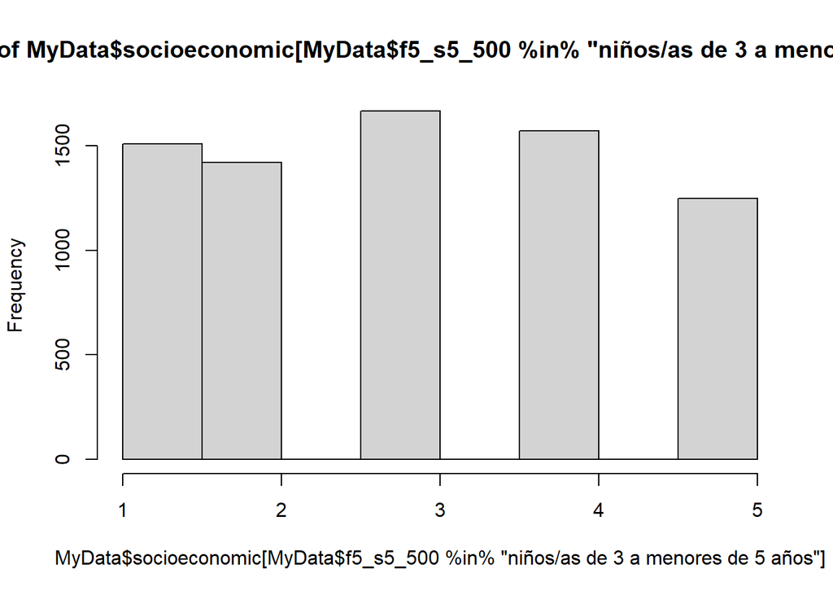

```r
library(fabricatr)
MyData$socioeconomic <- fabricatr::split_quantile(MyData$wealth, type = 5)
MyData$socioeconomic <-as.numeric(MyData$socioeconomic)
hist(MyData$socioeconomic[MyData$f5_s5_500 %in% "niños/as de 3 a menores de 5 años"])
```

### Mistimed or unintended pregnancy according to the father

This variable (‘f2_s4a_405_’) followed the same coding as that of the mother.

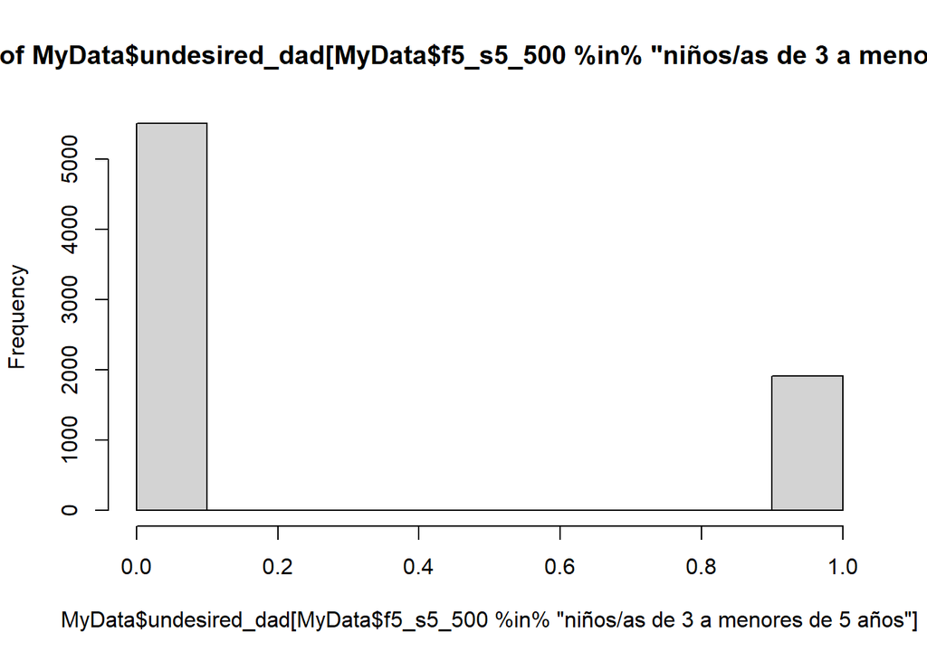

```r
MyData$f2_s4a_405_ <- as.factor(MyData$f2_s4a_405_)
MyData$undesired_dad <- ifelse(MyData$f2_s4a_405_ %in% "tener ese hijo?", 0,1)
hist(MyData$undesired_dad[MyData$f5_s5_500 %in% "niños/as de 3 a menores de 5 años"])
```

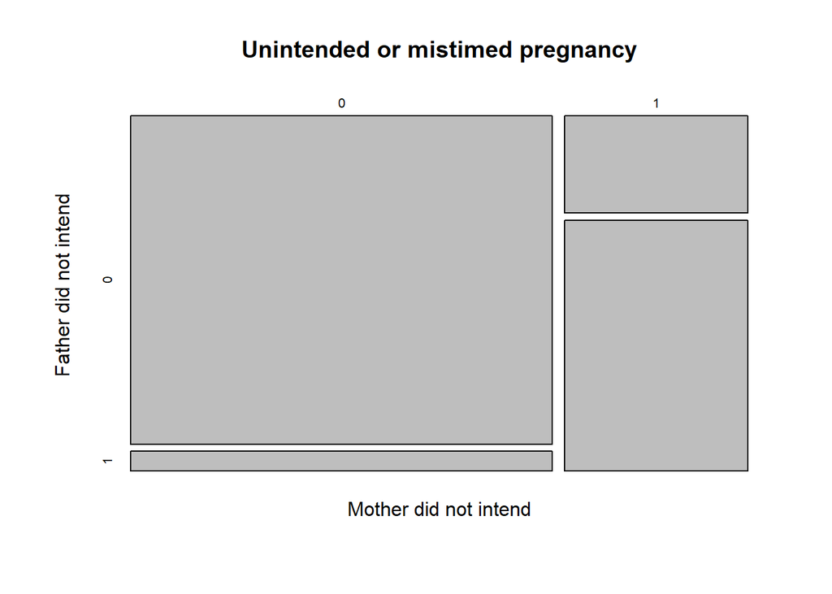

```r
mosaicplot(MyData$undesired_mom[MyData$f5_s5_500 %in% "niños/as de 3 a menores de 5 años"] ~ MyData$undesired_dad[MyData$f5_s5_500 %in% "niños/as de 3 a menores de 5 años"], main = "Unintended or mistimed pregnancy", ylab = "Father did not intend", xlab ="Mother did not intend")
```

### Maternal characteristics

The mother’s current marital status (‘f2_s9_900’) was recoded as married (married/common-law/living together), divorced_widow (divorced/widow/separated), and single (single). The mother’s age at the time of the interview (‘edadanios_mef’) is a numeric variable. Ethnicity (‘etnia’) is a categorical variable (Afro-Ecuadorian/White/Indigenous/Mestizo/Montubio or Other). Her educational level (‘nivins_mef’) was ordered as no education, primary, high school, and university. Finally, the mother present’s functional limitations related to depressive symptoms were extracted from the variable ‘f5_s14_1402’. This variable is answered only by mothers who manifested depressive symptoms in previous questions. The answer to “Because of the discomfort you have felt in the last 7 days, how difficult it has been for you to do your job, take care of housework, or get along with other people?” was coded 0 for those who were not asked the question and 1 to 4 from ‘not hard at all’ to ‘extremely hard’.

```r
#Marital status
MyData$f2_s9_900 <- as.factor(MyData$f2_s9_900)
summary(MyData$f2_s9_900[MyData$f5_s5_500 %in% "niños/as de 3 a menores de 5 años"])
```

```
##         casado?     divorciado?       separado?        soltero? unión de hecho?
##            2386             103             546             729              73
##    unión libre?          viudo?            NA's
##            2902              35             639
```

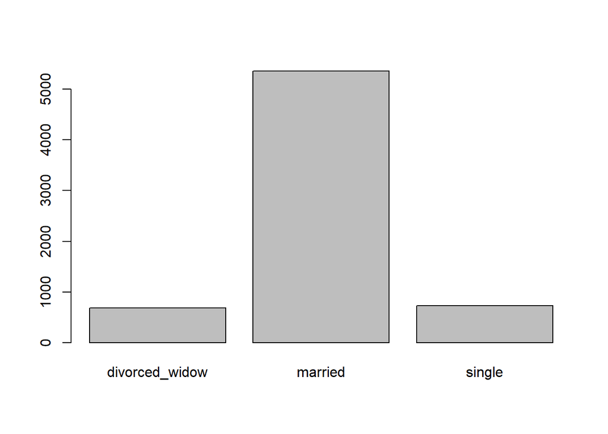

```r
MyData$marital <- car::recode(MyData$f2_s9_900, "'casado?'='married'; 'unión de hecho?'='married'; 'unión libre?'='married'; 'divorciado?'='divorced_widow'; 'separado?'='divorced_widow'; 'viudo?'='divorced_widow'; 'soltero?'='single'")
plot(MyData$marital[MyData$f5_s5_500 %in% "niños/as de 3 a menores de 5 años"])
```

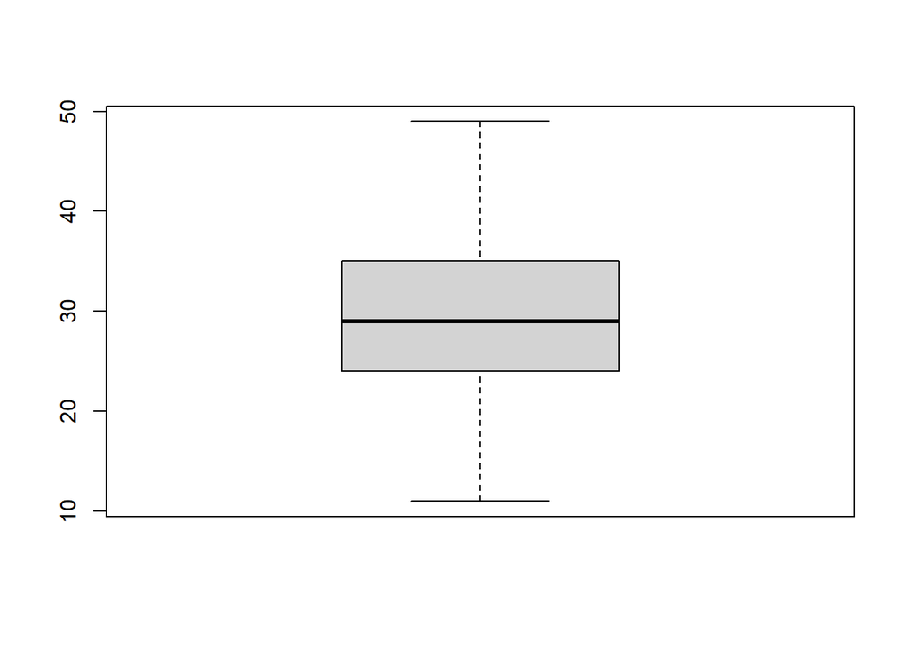

```r
#Mother age
boxplot(MyData$edadanios_mef[MyData$f5_s5_500 %in% "niños/as de 3 a menores de 5 años"])
```

```r
#Ethnicity
MyData$etnia <- as.factor(MyData$etnia)
summary(MyData$etnia[MyData$f5_s5_500 %in% "niños/as de 3 a menores de 5 años"])
```

```
## Afro-ecuatoriano           Blanco         Indígena          Mestizo
##              291               94              887             5838
## Montubio u Otros
##              303
```

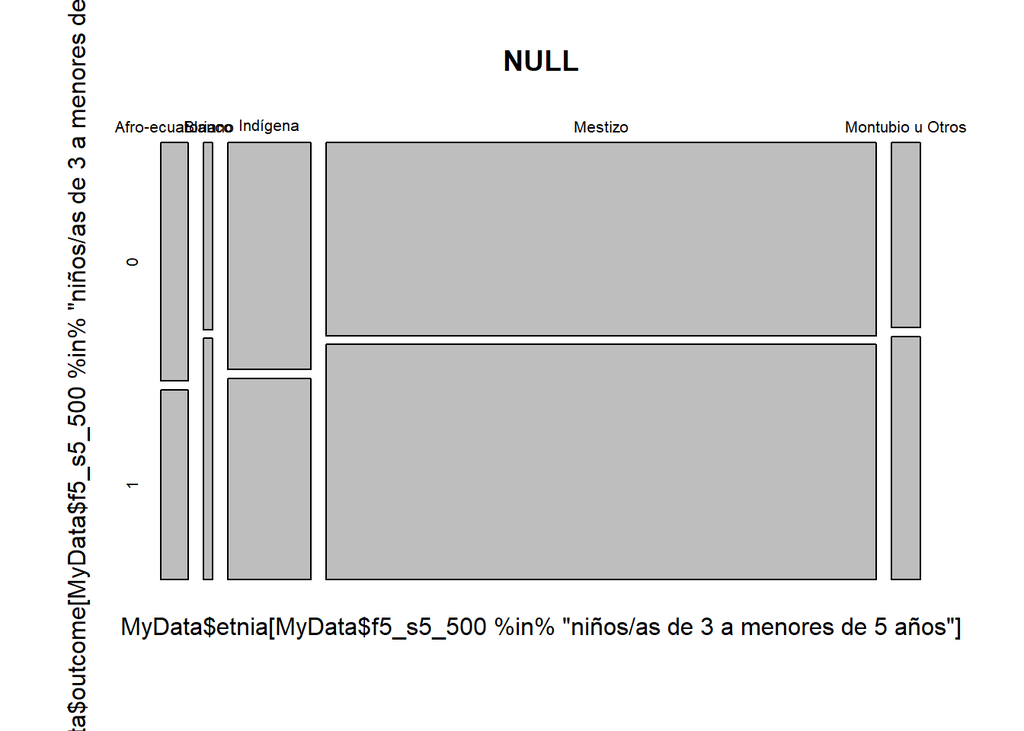

```r
mosaicplot(MyData$etnia[MyData$f5_s5_500 %in% "niños/as de 3 a menores de 5 años"]~MyData$outcome[MyData$f5_s5_500 %in% "niños/as de 3 a menores de 5 años"])
```

```r
#Mother education
MyData$nivins_mef <- ordered(MyData$nivins_mef, levels = c("Ninguno o Centro de Alfabetización", "Educación Básica", "Educación Media/Bachillerato", "Superior"))
summary(MyData$nivins_mef[MyData$f5_s5_500 %in% "niños/as de 3 a menores de 5 años"])
```

```
## Ninguno o Centro de Alfabetización                   Educación Básica
##                                 93                               2467
##       Educación Media/Bachillerato                           Superior
##                               2788                               1564
##                               NA's
##                                501
```

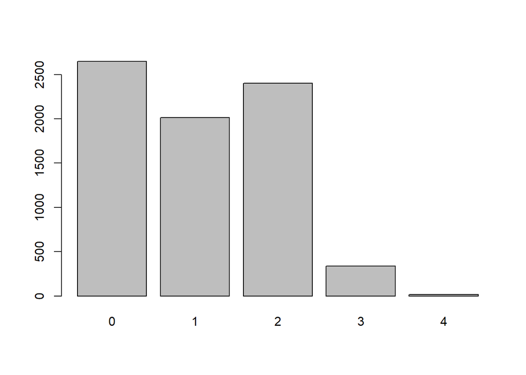

```r
#Construct - maternal depression affecting everyday life
MyData$f5_s14_1402 <- as.factor(MyData$f5_s14_1402)
MyData$maternal_depression <- car::recode(MyData$f5_s14_1402, "'extremadamente dificil'= '4'; 'muy dificil'= '3'; 'un pococ dificil'='2'; 'no ha sido dificil'='1'; else='0'")
plot(MyData$maternal_depression[MyData$f5_s5_500 %in% "niños/as de 3 a menores de 5 años"])
```

### Child characteristics

Age (‘gedad_meses’) groups children in three categories: 36-42, 43-47, and 48-59. Gender (‘sexo’) has two categories: man or woman.

```r
# Child_age
MyData$gedad_meses <- as.factor(MyData$gedad_meses)
summary(MyData$gedad_meses[MyData$f5_s5_500 %in% "niños/as de 3 a menores de 5 años"])
```

```
##  0-11 12-18 19-23 24-30 31-35 36-42 43-47 48-59
##     0     0     0     0     0  2078  1586  3749
```

```r
head(MyData$nivins_mef, 20)
```

```
##  [1] <NA>                         Superior
##  [3] Educación Básica             Educación Básica
##  [5] Superior                     Educación Media/Bachillerato
##  [7] Educación Básica             Educación Media/Bachillerato
##  [9] <NA>                         Superior
## [11] Educación Básica             Educación Media/Bachillerato
## [13] Superior                     Educación Media/Bachillerato
## [15] Educación Básica             Superior
## [17] <NA>                         Superior
## [19] Superior                     Superior
## 4 Levels: Ninguno o Centro de Alfabetización < ... < Superior
```

```r
head(MyData$mother_ed, 20)
```

[output not shown]

```r
# Child gender
MyData$sexo <- as.factor(MyData$sexo)
summary(MyData$sexo[MyData$f5_s5_500 %in% "niños/as de 3 a menores de 5 años"])
```

```
## hombre  mujer
##   3809   3604
```

## Other covariates

We also identified variables that might add precision to our model, might be potential mediators, or useful for stratified, subgroup, sensitivity, or secondary analysis. These variables included the number of months the child went to daycare–calculated as 0 for children who had not attended daycare (‘f5_s2_200’) and summing the values for years (‘f5_s2_204_1’) and months (‘f5_s2_204_2’) for all the others, whether or not the child was considered malnourished (‘dcronica’), whether or not the child attended classes with structured learning (‘f5_s5_511’). We also built an alternative exposure variable where either parent felt it was not the right time or outright did not want the child based on the variables reported above.

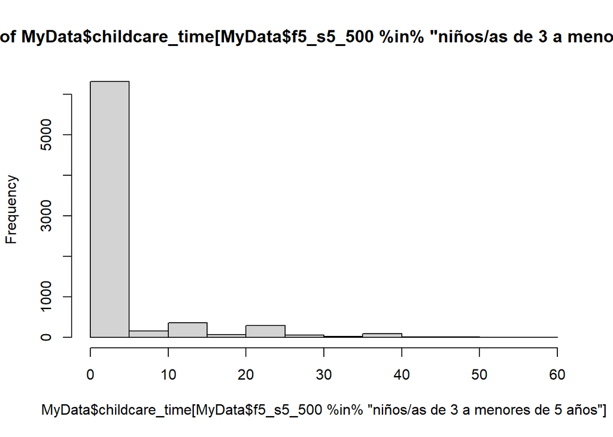

```r
#CONSTRUCT: Attending Childcare
#DATASET: Development
#VARIABLES: f5_s2_200 < Attending(Yes/No); MyData$f5_s2_204_1 < years attending; f5_s2_204_2 < months attending
#Construct: Months attending childcare

MyData$childcare_time <- ifelse(MyData$f5_s2_200 %in% "no", 0,MyData$f5_s2_204_2+MyData$f5_s2_204_1*12)
MyData$childcare_time <- ifelse(MyData$childcare_time <88,MyData$childcare_time,NA) #recoding NAs
hist(MyData$childcare_time[MyData$f5_s5_500 %in% "niños/as de 3 a menores de 5 años"])
```

```r
#Malnourished
MyData$dcronica <- as.factor(MyData$dcronica)
summary(MyData$dcronica[MyData$f5_s5_500 %in% "niños/as de 3 a menores de 5 años"])
```

```
##    0    1 NA's
## 5432 1264  717
```

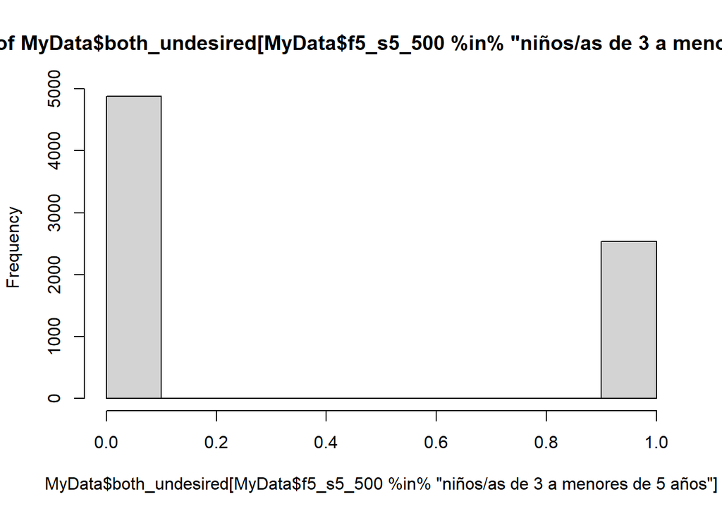

```r
#Alternative exposure
MyData$both_undesired <- ifelse(MyData$undesired_mom + MyData$undesired_dad ==0, 0, 1)
hist(MyData$both_undesired[MyData$f5_s5_500 %in% "niños/as de 3 a menores de 5 años"])
```

```r
#CONSTRUCT: Attending structured learning class
#DATASET: Development
#VARIABLE: f5_s5_511

MyData$f5_s5_511 <- as.factor(MyData$f5_s5_511)
summary(MyData$f5_s5_511[MyData$f5_s5_500 %in% "niños/as de 3 a menores de 5 años"])
```

```
##            no ns/nsr     si
##      0   3367     21   4025
```

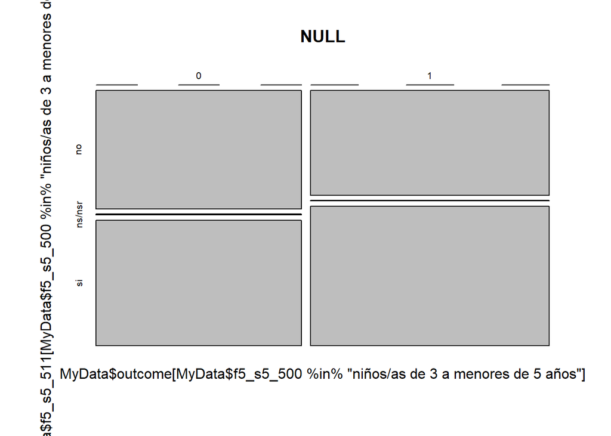

```r
mosaicplot(MyData$outcome[MyData$f5_s5_500 %in% "niños/as de 3 a menores de 5 años"] ~ MyData$f5_s5_511[MyData$f5_s5_500 %in% "niños/as de 3 a menores de 5 años"])
```